# 12_dist_point_to_line

## 12_dist_point_to_line

#### Question

1. Find the nearest distance from point $(13,-7)$ to line $y=-2x-21$.

   For flavor, imagine on a map, a river can be approximated by the line $y=-2x-21$. You are currently at position $(13,-7)$, and you want to know how far you need to travel to get to the river using the shortest path.

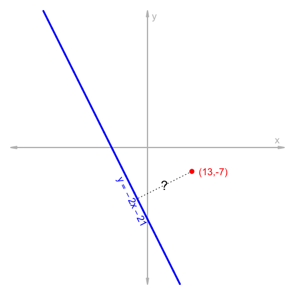

   What is the distance from the point to the line? Your answer should be accurate to within $\pm 0.01$.

#### Question

2. Find the nearest distance from point $(21,-26)$ to line $y=3x+1$.

   For flavor, imagine on a map, a river can be approximated by the line $y=3x+1$. You are currently at position $(21,-26)$, and you want to know how far you need to travel to get to the river using the shortest path.

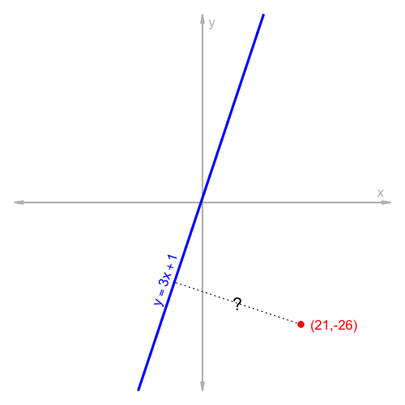

   What is the distance from the point to the line? Your answer should be accurate to within $\pm 0.01$.

#### Question

3. Find the nearest distance from point $(19,2)$ to line $y=\frac{-3}{5}x-7$.

   For flavor, imagine on a map, a river can be approximated by the line $y=\frac{-3}{5}x-7$. You are currently at position $(19,2)$, and you want to know how far you need to travel to get to the river using the shortest path.

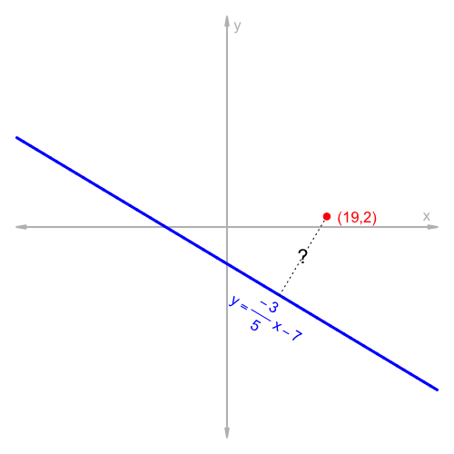

   What is the distance from the point to the line? Your answer should be accurate to within $\pm 0.01$.

#### Question

4. Find the nearest distance from point $(21,-17)$ to line $y=2x-19$.

   For flavor, imagine on a map, a river can be approximated by the line $y=2x-19$. You are currently at position $(21,-17)$, and you want to know how far you need to travel to get to the river using the shortest path.

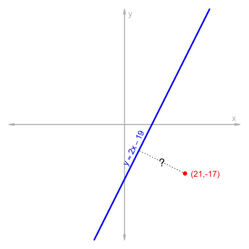

   What is the distance from the point to the line? Your answer should be accurate to within $\pm 0.01$.

#### Question

5. Find the nearest distance from point $(26,-9)$ to line $y=-6x-1$.

   For flavor, imagine on a map, a river can be approximated by the line $y=-6x-1$. You are currently at position $(26,-9)$, and you want to know how far you need to travel to get to the river using the shortest path.

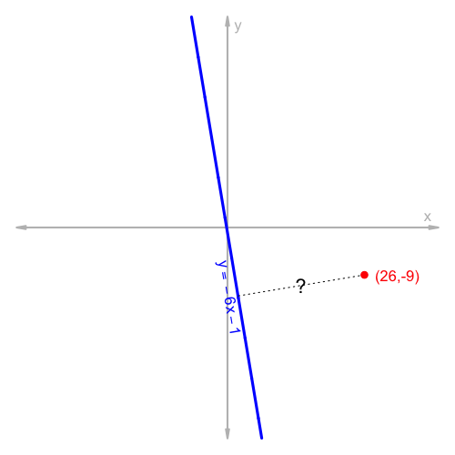

   What is the distance from the point to the line? Your answer should be accurate to within $\pm 0.01$.

#### Question

6. Find the nearest distance from point $(20,17)$ to line $y=\frac{1}{4}x-5$.

   For flavor, imagine on a map, a river can be approximated by the line $y=\frac{1}{4}x-5$. You are currently at position $(20,17)$, and you want to know how far you need to travel to get to the river using the shortest path.

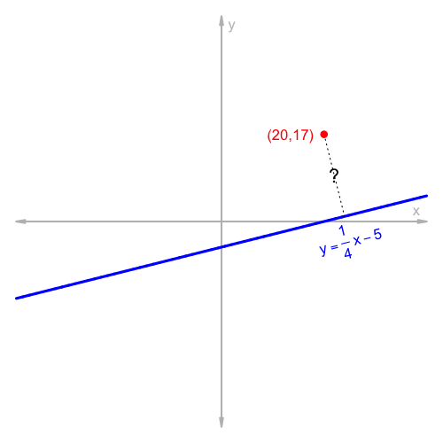

   What is the distance from the point to the line? Your answer should be accurate to within $\pm 0.01$.

#### Question

7. Find the nearest distance from point $(-2,16)$ to line $y=\frac{-3}{4}x-23$.

   For flavor, imagine on a map, a river can be approximated by the line $y=\frac{-3}{4}x-23$. You are currently at position $(-2,16)$, and you want to know how far you need to travel to get to the river using the shortest path.

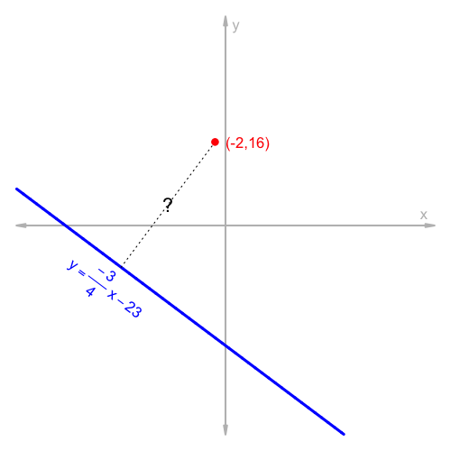

   What is the distance from the point to the line? Your answer should be accurate to within $\pm 0.01$.

#### Question

8. Find the nearest distance from point $(-19,20)$ to line $y=\frac{3}{2}x-23$.

   For flavor, imagine on a map, a river can be approximated by the line $y=\frac{3}{2}x-23$. You are currently at position $(-19,20)$, and you want to know how far you need to travel to get to the river using the shortest path.

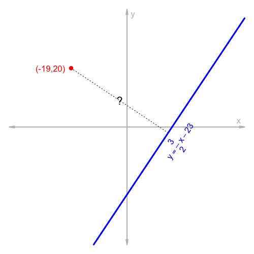

   What is the distance from the point to the line? Your answer should be accurate to within $\pm 0.01$.